# Dslabs Answer Key Ch. 2

Sabrina McNew

2023-09-07

### Load our libraries and set plot theme

```r
library(dslabs)
library(ggthemr)
library(tidyr)

ggthemr(palette = "flat", layout = "clean", text_size = 22)
```

## Dslabs: Introduction to Data Science Book First edition

## Chapter 2

### 2.3 Exercises:

1. What is the sum of the first 100 positive integers?

```r
n <- 100
n*(n+1)/2
```

```
## [1] 5050
```

2. Now use the same formula to compute the sum of the integers from 1 through 1,000.

```r
n <- 1000
n*(n+1)/2
```

```
## [1] 500500
```

3. Look at the result of typing the following code into R:

```r
n <- 1000
x <- seq(1, n)
sum(x)
```

```
## [1] 500500
```

Based on the result, what do you think the functions seq and sum do? You can use help.

Ans: seq() creates a sequence between two numbers, i.e. 1,2,3 sum() computes the sum of all the numbers in the sequence

4. In math and programming, we say that we evaluate a function when we replace the argument with a given number. So if we type sqrt(4), we evaluate the sqrt function. In R, you can evaluate a function inside another function. The evaluations happen from the inside out. Use one line of code to compute the log, in base 10, of the square root of 100.

```r
log10(sqrt(100))
```

```
## [1] 1
```

5. Which of the following will always return the numeric value stored in x? You can try out examples and use the help system if you want.

```r
x = 0
log(exp(x))
```

```
## [1] 0
```

### 2.5 Exercises

```r
murders <- murders
# 2.
str(murders)
```

```
## 'data.frame':    51 obs. of  5 variables:
##  $ state     : chr  "Alabama" "Alaska" "Arizona" "Arkansas" ...
##  $ abb       : chr  "AL" "AK" "AZ" "AR" ...
##  $ region    : Factor w/ 4 levels "Northeast","South",..: 2 4 4 2 4 4 1 2 2 2 ...
##  $ population: num  4779736 710231 6392017 2915918 37253956 ...
##  $ total     : num  135 19 232 93 1257 ...
```

```r
# 3.
class(murders$abb)
```

```
## [1] "character"
```

```r
# 4.
b <- murders[,2]
identical(b, murders$abb)
```

```
## [1] TRUE
```

```r
# 5.
class(murders$region)
```

```
## [1] "factor"
```

```r
levels(murders$region) %>% length
```

```
## [1] 4
```

```r
# 6.
table(murders$region)
```

```
##
##     Northeast         South North Central          West
##             9            17            12            13
```

Answers: 1. c: str() shows the state name, the abbreviation of the state name, the state’s region, and the state’s population and total number of murders for 2010.  
2. The names of the columns are: state, abb, region, population, and total. col_names() would also tell you this.  
3. The class of “abb” is “character.” 4. murders[,2] is the same as murders$abb, (and is the same as dplyr::select(murders, abb)) 5. There are four regions. 6. There are 9 states in NE, 17 in S, 12 in NC and 13 in W

### 2.8 Exercises

```r
# 1. Creating objects
temp <- c(35, 88, 42, 84, 81, 30)
# 2.
city <- c("Beijing", "Lagos", "Paris", "Rio de Janeiro", "San Juan", "Toronto")
# 3. add names to temperature vector
names(temp) <- city

# 4. Pull temps of the first three cities
temp[1:3]
```

```
## Beijing   Lagos   Paris
##      35      88      42
```

```r
# 5. Pull temps of Paris (#3) and San Juan (#5)
temp[c(3,5)]
```

```
##    Paris San Juan
##       42       81
```

```r
# 6. Sequencing
seq(from = 12, to = 73)
```

```
##  [1] 12 13 14 15 16 17 18 19 20 21 22 23 24 25 26 27 28 29 30 31 32 33 34 35 36
## [26] 37 38 39 40 41 42 43 44 45 46 47 48 49 50 51 52 53 54 55 56 57 58 59 60 61
## [51] 62 63 64 65 66 67 68 69 70 71 72 73
```

```r
# 7. Create a vector containing all positive odd numbers
# smaller than 100
seq(from = 1, to = 99, by = 2)
```

```
##  [1]  1  3  5  7  9 11 13 15 17 19 21 23 25 27 29 31 33 35 37 39 41 43 45 47 49
## [26] 51 53 55 57 59 61 63 65 67 69 71 73 75 77 79 81 83 85 87 89 91 93 95 97 99
```

```r
# 8. Create a vector of numbers that starts at 6, does not pass 55, and adds numbers in increments of 4/7: 6, 6 + 4/7, 6 + 8/7, and so on. How many numbers does the list have? Hint: use seq and length

seq(from = 6, to = 54, by = 4/7) %>% length
```

```
## [1] 85
```

```r
# 9: What is the class of the following object a <- seq(1, 10, 0.5)?
seq(1, 10, 0.5) %>% class
```

```
## [1] "numeric"
```

```r
# 10: What is the class of the following object a <- seq(1, 10)?
seq(1, 10) %>%  class
```

```
## [1] "integer"
```

```r
# 11. The class of class(a<-1) is numeric, not integer. R defaults to numeric and to force an integer, you need to add the letter L. Confirm that the class of 1L is integer.
class(1)
```

```
## [1] "numeric"
```

```r
class(1L)
```

```
## [1] "integer"
```

```r
# 12. Turn character vector into integer
x <- c("1", "3", "5")
class(x)
```

```
## [1] "character"
```

```r
as.integer(x) %>% class
```

```
## [1] "integer"
```

### 2.10

1. Use the $ operator to access the population size data and store it as the object pop. Then use the sort function to redefine pop so that it is sorted. Finally, use the [ operator to report the smallest population size.

```r
pop <- murders$population
pop <- sort(pop)
pop[1]
```

```
## [1] 563626
```

2. Now instead of the smallest population size, find the index of the entry with the smallest population size. Hint: use order instead of sort. Sabrina’s note: this is confusing. But basically order() tells us that the 51st entry in the list (Wyoming) has the smallest pop size, the ninth entry (DC) has the second smallest

```r
order(murders$population) %>% head
```

```
## [1] 51  9 46 35  2 42
```

```r
murders[9,]
```

```
##                  state abb region population total
## 9 District of Columbia  DC  South     601723    99
```

3. We can actually perform the same operation as in the previous exercise using the function which.min. Write one line of code that does this.

```r
which.min(murders$population)
```

```
## [1] 51
```

4. Now we know how small the smallest state is and we know which row represents it. Which state is it? Define a variable states to be the state names from the murders data frame. Report the name of the state with the smallest population. Sabrina note: This code works but just a philosophy it’s not a great idea to keep splitting up your data frame into other objects and assume that they’re still related. Once you break “states” out into its own vector it’s no longer associated with population and so indexes of each variable may not coincide.

```r
states <- murders$state
states[51]
```

```
## [1] "Wyoming"
```

```r
# Creating a dataframe
temp <- c(35, 88, 42, 84, 81, 30)
city <- c("Beijing", "Lagos", "Paris", "Rio de Janeiro",
          "San Juan", "Toronto")
city_temps <- data.frame(name = city, temperature = temp)
```

5. Use the rank function to determine the population rank of each state from smallest population size to biggest. Save these ranks in an object called ranks, then create a data frame with the state name and its rank. Call the data frame my_df.

```r
my_df <- data.frame(
  state = murders$state,
  rank = rank(murders$population))
head(my_df)
```

```
##        state rank
## 1    Alabama   29
## 2     Alaska    5
## 3    Arizona   36
## 4   Arkansas   20
## 5 California   51
## 6   Colorado   30
```

6. Repeat the previous exercise, but this time order my_df so that the states are ordered from least populous to most populous. Hint: create an object ind that stores the indexes needed to order the population values. Then use the bracket operator [ to re-order each column in the data frame.

```r
ind <- order(my_df$rank)
my_df[ind,] |> head() #check that it looks good
```

```
##                   state rank
## 51              Wyoming    1
## 9  District of Columbia    2
## 46              Vermont    3
## 35         North Dakota    4
## 2                Alaska    5
## 42         South Dakota    6
```

7. The na_example vector represents a series of counts.The is.na function returns a logical vector that tells us which entries are NA. Assign this logical vector to an object called ind and determine how many NAs does na_example have.
8. Compute the average, removing nas.

```r
data("na_example")
sum(is.na(na_example)) #how many entries of na_example are NA?
```

```
## [1] 145
```

```r
mean(na_example[!is.na(na_example)]) #calculate mean after removing NAs
```

```
## [1] 2.301754
```

```r
mean(na_example, na.rm = T) # gives same result
```

```
## [1] 2.301754
```

### 2.12 Exercises

1. Add a column with the temperature in C

```r
city_temps$temp_c <- 5/9 * (city_temps$temperature-32)
head(city_temps)
```

```
##             name temperature    temp_c
## 1        Beijing          35  1.666667
## 2          Lagos          88 31.111111
## 3          Paris          42  5.555556
## 4 Rio de Janeiro          84 28.888889
## 5       San Juan          81 27.222222
## 6        Toronto          30 -1.111111
```

2. What is the following sum? 1 + 1/2^2, 1/3(2)…

```r
x <- 1:100
sum(1/((x)^2))
```

```
## [1] 1.634984
```

```r
pi^2/6
```

```
## [1] 1.644934
```

3. Compute the per 100,000 murder rate for each state and store it in the object murder_rate. Then compute the average murder rate for the US using the function mean. What is the average?

```r
murders$murder_rate <- murders$total/(murders$population/100000)
mean(murders$murder_rate)
```

```
## [1] 2.779125
```

### 2.14 Exercises

1. Compute the per 100,000 murder rate for each state and store it in an object called murder_rate. Then use logical operators to create a logical vector named low that tells us which entries of murder_rate are lower than 1.

```r
low <- murders$murder_rate < 1
```

2. Now use the results from the previous exercise and the function which to determine the indices of murder_rate associated with values lower than 1.

```r
which(murders$murder_rate < 1)
```

```
##  [1] 12 13 16 20 24 30 35 38 42 45 46 51
```

3. Use the results from the previous exercise to report the names of the states with murder rates lower than 1.

```r
low_murder_states <- which(murders$murder_rate < 1)
murders$state[low_murder_states]
```

```
##  [1] "Hawaii"        "Idaho"         "Iowa"          "Maine"
##  [5] "Minnesota"     "New Hampshire" "North Dakota"  "Oregon"
##  [9] "South Dakota"  "Utah"          "Vermont"       "Wyoming"
```

```r
# other solutions
murders[murders$murder_rate < 1, 1 ]
```

```
##  [1] "Hawaii"        "Idaho"         "Iowa"          "Maine"
##  [5] "Minnesota"     "New Hampshire" "North Dakota"  "Oregon"
##  [9] "South Dakota"  "Utah"          "Vermont"       "Wyoming"
```

```r
murders[murders$murder_rate < 1, "state" ]
```

```
##  [1] "Hawaii"        "Idaho"         "Iowa"          "Maine"
##  [5] "Minnesota"     "New Hampshire" "North Dakota"  "Oregon"
##  [9] "South Dakota"  "Utah"          "Vermont"       "Wyoming"
```

```r
murders$state[murders$murder_rate < 1]
```

```
##  [1] "Hawaii"        "Idaho"         "Iowa"          "Maine"
##  [5] "Minnesota"     "New Hampshire" "North Dakota"  "Oregon"
##  [9] "South Dakota"  "Utah"          "Vermont"       "Wyoming"
```

4. Now extend the code from exercises 2 and 3 to report the states in the Northeast with murder rates lower than 1. Hint: use the previously defined logical vector low and the logical operator &.

```r
murders$state[murders$murder_rate < 1 & murders$region == "Northeast"]
```

```
## [1] "Maine"         "New Hampshire" "Vermont"
```

5. In a previous exercise we computed the murder rate for each state and the average of these numbers. How many states are below the average?

```r
murders$state[murders$murder_rate < mean(murders$murder_rate)] |> length()
```

```
## [1] 27
```

6. Use the match function to identify the states with abbreviations AK, MI, and IA. Hint: start by defining an index of the entries of murders$abb that match the three abbreviations, then use the [ operator to extract the states.

```r
murders[murders$abb %in% c("AK", "MI", "IA"),]
```

```
##       state abb        region population total murder_rate
## 2    Alaska  AK          West     710231    19   2.6751860
## 16     Iowa  IA North Central    3046355    21   0.6893484
## 23 Michigan  MI North Central    9883640   413   4.1786225
```

7. Use the %in% operator to create a logical vector that answers the question: which of the following are actual abbreviations: MA, ME, MI, MO, MU?

```r
test_abbs <- c("MA", "ME", "MI", "MO", "MU")
test_abbs %in% murders$abb #MU not a state
```

```
## [1]  TRUE  TRUE  TRUE  TRUE FALSE
```

### 2.16

1. We made a plot of total murders versus population and noted a strong relationship. Not surprisingly, states with larger populations had more murders.

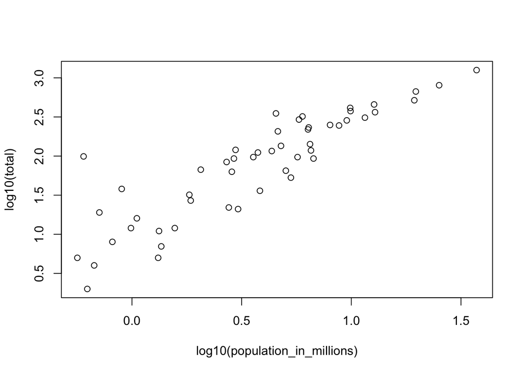

```r
murders$population_in_millions <- murders$population/10^6
plot(log10(total) ~ log10(population_in_millions), data = murders)
```

```r
# Sabrina note: Irizarry here isn't using the formula notation plot(y ~ x, data = data)
# for base plotting but it is superior so that's what I'm doing. I am also
# opting to add these new variables as columns to the murders dataframe to avoid orphaned
# variables like I mentioned above. Usually it's better to keep things in data frames
# and not assign too many random variables to the environment.
```

2. Create histograms of state populations
3. Create boxplots of state pops by region

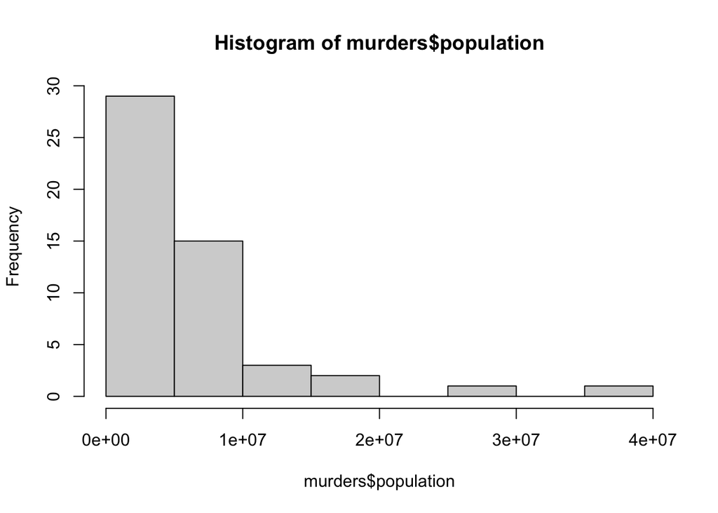

```r
hist(murders$population)
```

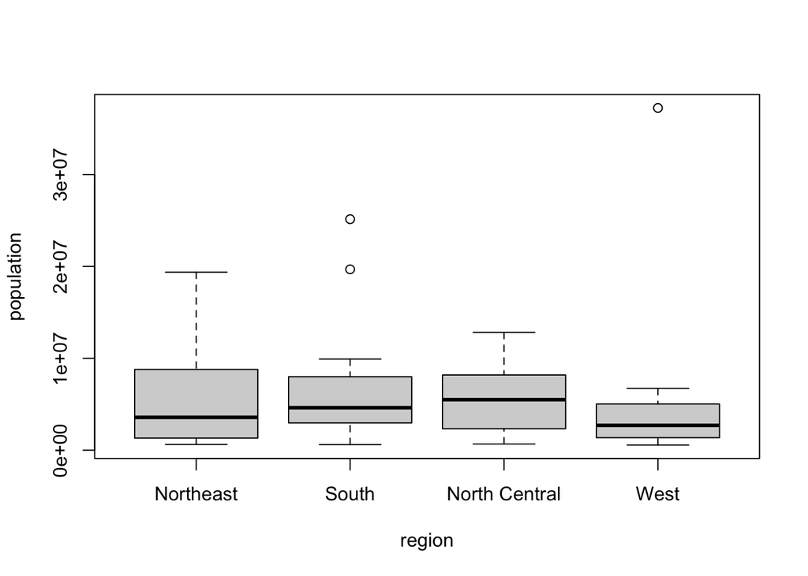

```r
boxplot(population ~ region, data = murders)
```